Đo lường trong giáo dục · Lý thuyết Ứng đáp Câu hỏi

# Đo lường năng lực người học: Mô hình Rasch, so sánh CTT–IRT và Lý thuyết Ứng đáp Câu hỏi

Năng lực là một đại lượng tiềm ẩn — không quan sát trực tiếp được mà chỉ suy ra qua chuỗi trả lời đúng/sai của học sinh. Bài viết trình bày cách định vị năng lực trong mô hình Rasch, đối chiếu hai lý thuyết đo lường CTT và IRT, và giới thiệu khung hình thức đầy đủ của IRT.

01 — Mô hình Rasch

## Xác định vị trí năng lực học sinh trong mô hình Rasch

### 1.1. Mục đích của việc định vị

Khi dùng Lý thuyết Ứng đáp Câu hỏi nói chung và mô hình Rasch nói riêng để triển khai một bài trắc nghiệm, mục đích quan trọng nhất là xác định được *vị trí của học sinh trên thang đo năng lực*. Khi đã có một số đo năng lực như vậy cho mỗi học sinh, ta đạt được đồng thời hai điều: đánh giá mức năng lực của từng em, và so sánh năng lực giữa các em để phân loại hay tuyển chọn theo một tiêu chuẩn nào đó.<sup>1</sup>

Điểm khác biệt căn bản so với cách chấm điểm cổ điển là: vị trí năng lực trong mô hình Rasch được đặt trên một thang đo chung, về nguyên tắc không phụ thuộc vào đề trắc nghiệm cụ thể mà học sinh đã làm. Nhờ vậy nó là một đại lượng ổn định, dùng để mô tả mức phát triển của học sinh chứ không chỉ là số điểm trên một đề.

### 1.2. Hai giả định nền tảng

Mô hình toán về phép đo trong giáo dục được xây dựng từ các *mối tương tác* giữa một học sinh và một câu hỏi — đơn vị cơ sở để dựng nên toàn bộ lý thuyết. Để mô hình khả thi, người ta giữ lại quan hệ bản chất nhất và lược bỏ các yếu tố phụ, dựa trên hai giả định:

- **Tính đơn chiều (unidimensionality):** chỉ một loại năng lực tiềm ẩn chi phối việc trả lời các câu hỏi trong đề. Trên thực tế còn nhiều yếu tố khác tác động (động cơ, sự hồi hộp, xu hướng đoán mò, tốc độ làm bài…), nên cần thiết kế đề sao cho khu biệt được thành phần chính — chính thành phần đó được xem là năng lực tiềm ẩn cần đo.
- **Tính độc lập địa phương (local independence):** khi giữ năng lực không đổi, ứng đáp của học sinh với hai câu hỏi bất kỳ độc lập với nhau về mặt thống kê; năng lực được mô hình hóa là yếu tố duy nhất ảnh hưởng đến việc trả lời. Ví dụ: nếu học sinh làm bài Toán nhưng có em đọc tiếng Việt chưa thạo, thì năng lực đọc sẽ chen vào ảnh hưởng đến kết quả, và tính độc lập địa phương không còn được bảo đảm.

### 1.3. Đặt năng lực và độ khó trên cùng một thang đo

Muốn đo năng lực học sinh qua các câu hỏi, ta phải so sánh được *năng lực của học sinh* với *độ khó của câu hỏi*. Hai đại lượng này vốn có thứ nguyên và ý nghĩa khác hẳn nhau nên thông thường không so sánh trực tiếp được. Mô hình giải quyết bằng cách biểu diễn cả hai trên cùng một trục liên tục, từ $-\infty$ đến $+\infty$, và quy về dạng không thứ nguyên: lấy trung bình của phân bố làm điểm gốc (0) và độ lệch tiêu chuẩn làm đơn vị (1). Khi năng lực $\theta$ và độ khó $b$ cùng nằm trên một thang như vậy, chúng trở nên so sánh được — đây là tiền đề cho phép định vị học sinh so với các câu hỏi.

### 1.4. Mô hình Rasch và đường cong đặc trưng câu hỏi

Mô hình ứng đáp câu hỏi là mô hình *xác suất*, không phải tất định. Nhà toán học Đan Mạch George Rasch xuất phát từ một nhận định đơn giản và hợp lý: học sinh có năng lực cao hơn thì xác suất trả lời đúng một câu hỏi bất kỳ phải lớn hơn; một câu hỏi khó hơn thì xác suất để bất kỳ học sinh nào trả lời đúng phải nhỏ hơn.<sup>2</sup> Từ đó suy ra xác suất trả lời đúng phụ thuộc vào *tương quan giữa năng lực học sinh và độ khó câu hỏi*.

Rasch chỉ dùng một tham số cho câu hỏi là độ khó (vì thế gọi là mô hình một tham số). Gọi $P$ là xác suất trả lời đúng, ông chọn hàm odds $P/(1-P)$ rồi lấy logarit tự nhiên, thu được biểu thức tuyến tính theo hiệu giữa năng lực và độ khó:

$$\ln\!\left(\frac{P}{1-P}\right) = \theta - b$$

trong đó $\ln[P/(1-P)]$ được gọi là **logit**. Biến đổi ngược lại, ta được hàm đặc trưng câu hỏi của mô hình Rasch:

$$P(\theta) = \frac{e^{\,\theta - b}}{1 + e^{\,\theta - b}}$$

Đây là một hàm logistic, đồng biến theo $\theta$ và nhận giá trị trong khoảng $(0,1)$. Đồ thị của nó là **đường cong đặc trưng câu hỏi** (ICC): năng lực càng cao thì xác suất trả lời đúng càng lớn; xác suất tiến tới 0 khi năng lực rất thấp so với độ khó, và tiến tới 1 khi năng lực rất cao so với độ khó.

### 1.5. Vị trí năng lực chính là điểm xác suất 0,5

Từ hàm trên, khi năng lực của học sinh bằng đúng độ khó câu hỏi, tức $\theta = b$, ta có $P = 0{,}5$. Đây là điểm tựa để định vị: **vị trí năng lực của một học sinh là mức độ khó câu hỏi mà tại đó em có xác suất trả lời đúng bằng một nửa.** Quanh vị trí ấy, con đường học tập của em chia thành ba phần:

Ba vùng quanh vị trí năng lực $\theta$

| Quan hệ độ khó – năng lực | Xác suất đúng | Ý nghĩa |
| --- | --- | --- |
| $b < \theta$ (câu dưới tầm) | $> 0{,}5$ | Phần học sinh đã làm chủ |
| $b \approx \theta$ (ngang tầm) | quanh $0{,}5$ | Phần vừa sức — thích hợp để dạy và luyện |
| $b > \theta$ (câu vượt tầm) | $< 0{,}5$ | Phần còn quá sức |

Trong thực hành, kết quả định vị được thể hiện trực quan bằng giản đồ đặt học sinh và câu hỏi trên *cùng một trục năng lực* (bản đồ thí sinh – câu hỏi)<sup>8</sup>: một bên là các học sinh sắp theo năng lực từ thấp đến cao, bên kia là các câu hỏi sắp theo độ khó. Vì hai bên cùng một thang đo, người giáo viên đọc được ngay học sinh đang ở mức nào, đã vượt qua những câu hỏi nào, và câu hỏi nào là bước tiếp theo vừa tầm.

### 1.6. Ước lượng vị trí năng lực từ bài làm

Sau khi học sinh làm xong đề, ta thu được một dãy trả lời đúng/sai với từng câu — gọi là *vectơ ứng đáp* của em. Bài toán là dùng vectơ ứng đáp đó cùng các độ khó đã biết để ước lượng năng lực chưa biết của học sinh, bằng phương pháp **biến cố hợp lý cực đại** (maximum likelihood). Nhờ tính độc lập địa phương, xác suất của cả dãy ứng đáp bằng tích các xác suất từng câu; lấy logarit ta được:

$$\ln L(\mathbf{u}\mid\theta)=\sum_{j=1}^{n}\big[\,u_j\ln P_j+(1-u_j)\ln(1-P_j)\,\big]$$

Giá trị $\theta$ làm cho hàm này đạt cực đại được xem là ước lượng năng lực của học sinh, tìm bằng phép lặp: gán giá trị ban đầu, tính xác suất trả lời đúng từng câu, rồi điều chỉnh dần cho đến khi bước điều chỉnh đủ nhỏ.

Một đặc điểm riêng của mô hình Rasch: tổng số câu trả lời đúng đã đủ để xác định vị trí năng lực. Hai học sinh có cùng số câu đúng sẽ được đặt vào cùng một vị trí trên thang đo, bất kể đúng những câu nào. Nhờ vậy con số quen thuộc "làm đúng bao nhiêu câu" được chuyển một cách nhất quán thành vị trí trên đường phát triển năng lực.

Lưu ý — điểm biên Học sinh trả lời đúng *toàn bộ* hoặc sai *toàn bộ* không cho một vị trí hữu hạn, vì đề chưa chạm tới giới hạn năng lực của em; khi đó cần một đề có độ khó phù hợp hơn để định vị chính xác.

### 1.7. Độ chính xác của vị trí: hàm thông tin và sai số tiêu chuẩn

Một ưu điểm quan trọng của mô hình là cho biết vị trí được xác định *chính xác đến đâu*, và độ chính xác này thay đổi theo từng mức năng lực. Lượng "thông tin" mà một câu hỏi cung cấp để xác định năng lực được đo bằng **hàm thông tin câu hỏi**;<sup>4</sup> với mô hình Rasch, biểu thức rút gọn thành:

$$I_j(\theta)=P_j(\theta)\,[1-P_j(\theta)]$$

Hàm này đạt cực đại tại $\theta=b_j$ — một câu hỏi cung cấp nhiều thông tin nhất về những học sinh có năng lực ngang với độ khó của nó. Hàm thông tin của cả đề là tổng thông tin các câu, do mỗi câu đóng góp độc lập:

$$I(\theta)=\sum_{j=1}^{n}I_j(\theta),\qquad \sigma(\theta)=\frac{1}{\sqrt{I(\theta)}}$$

Như vậy sai số của phép đo *không cố định* mà thay đổi theo mức năng lực — một biểu hiện của việc "cá thể hóa" phép đo trong IRT, và là điểm khác biệt rõ rệt so với lý thuyết cổ điển (vốn coi sai số như nhau cho mọi học sinh). Hệ quả thực tiễn: một đề đo rất chính xác ở khoảng năng lực có nhiều câu hỏi phù hợp, nhưng kém chính xác ở khoảng thưa câu hỏi. Muốn định vị tốt một nhóm học sinh, đề cần đủ câu hỏi ở đúng khoảng năng lực của nhóm đó.

Cuối cùng, một vị trí $\hat\theta$ chỉ thực sự đáng tin khi *kiểu trả lời* của học sinh phù hợp với mô hình. Các chỉ số *infit/outfit* (xem mục 3.8) cảnh báo những kiểu trả lời bất thường — em giỏi sai câu dễ, hoặc em yếu đúng câu khó — để giáo viên xem xét kỹ hơn trước khi dùng vị trí đó cho quyết định dạy học.

### 1.8. Tóm lại

Định vị năng lực trong mô hình Rasch dựa trên ba ý cốt lõi. **Một**, năng lực học sinh và độ khó câu hỏi được đặt trên cùng một thang đo nên so sánh được. **Hai**, qua hàm đặc trưng câu hỏi, vị trí học sinh là điểm có xác suất trả lời đúng bằng 0,5 — ranh giới giữa phần đã làm chủ, phần vừa sức và phần quá sức. **Ba**, vị trí ấy được ước lượng từ vectơ ứng đáp bằng biến cố hợp lý cực đại, với độ chính xác thay đổi theo từng mức năng lực do hàm thông tin quy định. Kết quả là một số đo gắn với việc *học sinh có thể làm được gì*, làm cơ sở để theo dõi phát triển và tổ chức dạy học phù hợp.

02 — Hai lý thuyết đo lường

## So sánh lý thuyết trắc nghiệm cổ điển (CTT) và lý thuyết ứng đáp câu hỏi (IRT)

### 2.1. Hạn chế gốc rễ của CTT

Phát triển từ đầu thế kỷ XX đến thập niên 1970, lý thuyết trắc nghiệm cổ điển đạt nhiều thành tựu nhưng còn vướng những hạn chế bản chất. Hạn chế cơ bản nhất là CTT *không tách bạch được đặc trưng của học sinh với đặc trưng của đề*: hai loại đặc trưng này chỉ giải thích được trong quan hệ với nhau.<sup>1</sup>

Cụ thể, trong CTT năng lực được biểu diễn bằng điểm số trên một đề cụ thể, còn độ khó câu hỏi được định nghĩa là tỷ lệ học sinh làm đúng câu đó. Hệ quả là một vòng phụ thuộc luẩn quẩn: đề "khó" làm học sinh có vẻ kém năng lực, nhóm học sinh giỏi lại làm câu hỏi có vẻ dễ. Vì đặc trưng của câu hỏi và của học sinh thay đổi theo nhau, rất khó — về nguyên tắc là không thể — so sánh hai học sinh làm hai đề khác nhau, hay hai câu hỏi được trả lời bởi hai nhóm khác nhau. Ngoài ra:

- CTT định nghĩa độ tin cậy qua "hai đề tương đương" — điều khó thỏa mãn trong thực tế — và coi sai số tiêu chuẩn là *như nhau* cho mọi học sinh, trong khi độ chính xác thực tế khác nhau ở các mức năng lực khác nhau.
- CTT xét ứng đáp ở cấp độ *đề* chứ không ở cấp độ *câu hỏi*, nên không trả lời được câu hỏi rất quan trọng trong thực tiễn: "xác suất để một học sinh xác định trả lời đúng một câu hỏi cụ thể là bao nhiêu?".

Từ những giới hạn đó, các nhà tâm trắc học kỳ vọng một lý thuyết mới đáp ứng năm yêu cầu: (1) đặc trưng câu hỏi không phụ thuộc nhóm học sinh; (2) điểm năng lực không phụ thuộc đề cụ thể; (3) mô hình hóa ở cấp độ câu hỏi; (4) không đòi hỏi các đề hoàn toàn tương đương để đánh giá độ tin cậy; (5) cung cấp độ chính xác khác nhau ở từng mức năng lực. IRT chính là lý thuyết đạt được cả năm kỳ vọng này.<sup>1</sup>

Gắn với điều này là cách hai lý thuyết hiểu "điểm": CTT dừng ở *điểm thô* (số câu đúng trên một đề), còn IRT phân biệt rõ điểm thô, *điểm thực* và *điểm năng lực* $\theta$ — chỉ $\theta$ mới độc lập với đề và so sánh được giữa các đề (xem mục 3.6).<sup>1</sup>

### 2.2. Bảng so sánh

Đối chiếu CTT và IRT theo các tiêu chí chính

| Tiêu chí | CTT — Lý thuyết cổ điển | IRT — Lý thuyết ứng đáp câu hỏi |
| --- | --- | --- |
| Đơn vị phân tích | Cấp độ đề: điểm = tổng điểm các câu | Cấp độ câu hỏi: từng tương tác học sinh–câu hỏi |
| Đại lượng năng lực | Điểm thô, phụ thuộc đề | Tham số $\theta$ trên thang chung, độc lập đề |
| Tham số câu hỏi | Độ khó = tỷ lệ đúng; độ phân biệt = tương quan câu–tổng | $a,b,c$ — cùng thang với $\theta$ |
| Tính bất biến | Không: đặc trưng câu hỏi đổi theo nhóm; điểm đổi theo đề | Có (khi mô hình phù hợp): sample-free, item-free |
| Sai số đo | Một giá trị chung cho mọi học sinh | Thay đổi theo từng mức năng lực, qua hàm thông tin |
| Độ tin cậy | Định nghĩa qua "hai đề tương đương" — khó thỏa mãn | Thay bằng hàm thông tin $I(\theta)$, cục bộ |
| Dự báo ứng đáp | Không trả lời được "xác suất đúng câu này?" | Trả lời trực tiếp qua $P(\theta)$ |
| Yêu cầu mẫu | Mẫu nhỏ vẫn dùng được | Cần mẫu lớn hơn để định cỡ ổn định |
| Giả định | Tối thiểu, dễ áp dụng | Đơn chiều + độc lập địa phương + dạng hàm; phải kiểm định |
| Ứng dụng mạnh | Đề đơn lẻ, đánh giá lớp học | Ngân hàng câu hỏi, trắc nghiệm thích ứng, so bằng, phát hiện câu thiên lệch |

### 2.3. "Hòn đá tảng": tính bất biến

Ưu thế cốt lõi phân biệt IRT với CTT là **tính bất biến** của tham số. Khi mô hình phù hợp tốt với số liệu, tham số câu hỏi không phụ thuộc nhóm học sinh dùng để định cỡ ("không phụ thuộc mẫu thử" — sample-free), và năng lực ước lượng không phụ thuộc tập câu hỏi cụ thể đem ra đo ("không phụ thuộc câu hỏi" — item-free). Đây là điều CTT không có, và là cơ sở để xây dựng, mở rộng ngân hàng câu hỏi trên cùng một thang, tính trước được hàm thông tin và đặc trưng của đề ngay cả trước khi tổ chức thi, cũng như so bằng điểm giữa các đề.<sup>1</sup><sup>5</sup>

Cần lưu ý Tính bất biến là tính chất của mô hình hồi quy phi tuyến *khi nó khớp tốt với số liệu*, không phải một sự bảo đảm tự nhiên. Nếu mô hình không phù hợp, tính bất biến không còn. Vì thế khâu kiểm định độ phù hợp giữa mô hình và số liệu là điều kiện tiên quyết trong IRT — điều mà CTT không đặt ra.

03 — Lý thuyết IRT

## Trình bày Lý thuyết Ứng đáp Câu hỏi (IRT)

### 3.1. Tư tưởng cốt lõi

IRT là một họ mô hình xác suất mô tả mối quan hệ giữa năng lực tiềm ẩn của học sinh và xác suất ứng đáp của em với từng câu hỏi. Đơn vị phân tích không phải là đề thi mà là *mối tương tác nguyên tố* "học sinh – câu hỏi" — tế bào để dựng nên toàn bộ lý thuyết. Năng lực $\theta$ được hình dung như một điểm trên một đường liên tục; xác suất đáp đúng là một hàm của khoảng cách giữa năng lực học sinh và độ khó câu hỏi.

### 3.2. Giả định

IRT dựa trên hai giả thiết: (1) ứng đáp của học sinh với một câu hỏi có thể tiên đoán bằng năng lực tiềm ẩn của em; (2) quan hệ giữa ứng đáp và năng lực mô tả được bằng một hàm đặc trưng câu hỏi đồng biến. Kèm theo là hai giả định nền đã nêu ở Phần 1: **tính đơn chiều** và **tính độc lập địa phương**. Nhờ độc lập địa phương, xác suất của cả vectơ ứng đáp bằng tích các xác suất từng câu:

$$P(\mathbf{u}\mid\theta)=\prod_{j=1}^{n}P_j(\theta)^{u_j}\,[1-P_j(\theta)]^{1-u_j}$$

### 3.3. Ba mô hình câu hỏi nhị phân

Tùy theo số tham số dùng để mô tả câu hỏi, có ba mô hình thông dụng (với $D\approx1{,}7$ là hằng số đưa hàm logistic về xấp xỉ hàm vòm chuẩn; có thể đặt $D=1$):

- **Mô hình một tham số (Rasch / 1PL)**<sup>2</sup> — chỉ độ khó $b$, giả định mọi câu có cùng độ phân biệt: $$P_j(\theta)=\frac{1}{1+e^{-(\theta-b_j)}}$$
- **Mô hình hai tham số (2PL)** — thêm độ phân biệt $a_j$ (độ dốc đường cong): $$P_j(\theta)=\frac{1}{1+e^{-a_j(\theta-b_j)}}$$
- **Mô hình ba tham số (3PL / Birnbaum)**<sup>4</sup> — thêm tham số đoán mò $c_j$ (tiệm cận dưới): $$P_j(\theta)=c_j+(1-c_j)\,\frac{1}{1+e^{-a_j(\theta-b_j)}}$$

Ba tham số có ba ý nghĩa hình học rõ ràng: $b$ định *vị trí* đường cong trên trục năng lực, $a$ định *độ dốc* (câu càng dốc càng phân biệt mạnh quanh $b$), còn $c$ nâng *sàn* của đường cong lên (xác suất đúng do đoán mò ngay cả khi năng lực rất thấp).

Ngoài ba mô hình nhị phân, IRT còn có các mở rộng cho câu hỏi *đa phân* (chấm theo nhiều mức điểm) và *đa chiều* (khi giả định đơn chiều bị vi phạm rõ). Về lựa chọn mô hình, việc so sánh thường dựa trên các tiêu chí như AIC/BIC; cần lưu ý ở cỡ mẫu rất lớn, BIC có xu hướng thiên về mô hình ít tham số (Rasch) một phần do chính cấu trúc tiêu chí, nên kết luận chọn mô hình cần được diễn giải thận trọng.<sup>1</sup>

### 3.4. Thang logit và các dạng hàm đặc trưng khác

Cùng một đường cong đặc trưng câu hỏi có thể biểu diễn trên nhiều *metric* (dạng tính) khác nhau. Ba dạng thường gặp:

- **Dạng logit (log-odds).** Lấy logarit của tỷ số odds cho quan hệ tuyến tính $\ln[P/(1-P)] = a(\theta-b)$ (với Rasch, $a=1$). Đơn vị của thang là *logit*: mỗi đơn vị logit ứng với việc nhân tỷ số odds trả lời đúng lên $e\approx 2{,}718$ lần. Đây là dạng tuyến tính, thuận tiện để ước lượng và để đặt năng lực, độ khó lên cùng một thang.<sup>1</sup>
- **Dạng logistic.** Giải ngược từ logit cho hàm logistic $P(\theta)=1/\big(1+e^{-a(\theta-b)}\big)$ — dạng phổ biến nhất hiện nay nhờ biểu thức đơn giản và tính toán nhanh.
- **Dạng vòm chuẩn (normal ogive).** Trước khi hàm logistic phổ biến, các nhà tâm trắc học dùng đường cong tích lũy của phân bố chuẩn làm hàm đặc trưng câu hỏi:<sup>3</sup> $$P(\theta)=\int_{-\infty}^{\,a(\theta-b)}\frac{1}{\sqrt{2\pi}}\,e^{-t^2/2}\,dt$$ (mô hình ba tham số thêm sàn $c$ tương tự dạng logistic). Dạng này có cơ sở từ phân bố chuẩn nhưng phải tính tích phân nên tốn kém.

**Quan hệ giữa hai dạng và hằng số $D$.** Haley (1952) chỉ ra rằng nếu nhân tham số độ dốc $a$ của hàm logistic với hằng số $D=1{,}702$ thì sai khác tuyệt đối giữa xác suất theo hàm logistic và theo hàm vòm chuẩn nhỏ hơn $0{,}01$ trên toàn thang $\theta$.<sup>1</sup> Nói cách khác, với $D\approx 1{,}7$ hai dạng gần như trùng nhau. Vì thế nhiều phần mềm viết hàm logistic dưới dạng $P(\theta)=1/\big(1+e^{-Da(\theta-b)}\big)$ để tham số $a$ diễn giải được theo metric vòm chuẩn quen thuộc, trong khi vẫn giữ ưu điểm tính toán của hàm logistic.

**Dạng độ dốc – giao điểm (slope–intercept).** Trong tính toán, biểu thức $a(\theta-b)$ thường được viết lại thành $a\theta + d$ với $d=-ab$ ($d$ gọi là tham số giao điểm). Đây chỉ là một cách tham số hóa khác của cùng một đường cong, tiện cho việc ước lượng số.

### 3.5. Hàm thông tin và độ chính xác

Lượng thông tin một câu hỏi cung cấp về năng lực ở mỗi mức $\theta$ được tính theo công thức của Birnbaum:<sup>4</sup>

$$I_j(\theta)=\frac{[P_j'(\theta)]^2}{P_j(\theta)\,[1-P_j(\theta)]}$$

Suy ra cho từng mô hình: với 2PL, $I_j(\theta)=a_j^2\,P_j(\theta)Q_j(\theta)$; với Rasch ($a_j=1$), $I_j(\theta)=P_j(\theta)Q_j(\theta)$. Thông tin của cả đề là tổng thông tin các câu, $I(\theta)=\sum_j I_j(\theta)$ — chính tính cộng tính này (do mỗi câu đóng góp độc lập) là điểm khác biệt then chốt với CTT. Sai số tiêu chuẩn của ước lượng năng lực liên hệ nghịch với thông tin: $\sigma(\theta)=1/\sqrt{I(\theta)}$, nên đề càng dài và càng nhiều câu phù hợp với một khoảng năng lực thì đo khoảng đó càng chính xác. Đặc tính này cho phép thiết kế đề có hàm thông tin tập trung ở vùng năng lực mong muốn — ví dụ dồn thông tin quanh điểm cắt để phân loại đạt/không đạt.

### 3.6. Hàm đặc trưng đề và điểm thực

Các câu hỏi thường được tập hợp thành một đề. Cộng các hàm đặc trưng câu hỏi của cả đề, ta được kỳ vọng số câu trả lời đúng của một học sinh có năng lực $\theta$ — đại lượng này gọi là **điểm thực** (true score), là một hàm theo $\theta$:

$$\tau(\theta)=E(X)=\sum_{j=1}^{n}P_j(\theta)$$

Đồ thị của $\tau(\theta)$ là **đường cong đặc trưng của đề** (test characteristic curve), cũng tăng dần như đường cong từng câu nhưng nhận giá trị từ $0$ đến $n$. Hàm này là cầu nối giữa thang năng lực $\theta$ (trừu tượng) và số câu đúng (quen thuộc): biết $\theta$ của học sinh, ta dự báo được em làm đúng khoảng bao nhiêu câu, và ngược lại.

Từ đây phân biệt ba loại điểm: *điểm thô* — số câu đúng quan sát được trên một đề cụ thể (quan niệm của CTT); *điểm thực* $\tau(\theta)$ — kỳ vọng số câu đúng, vẫn gắn với một đề cụ thể; và *điểm năng lực* $\theta$ — vị trí trên thang chung, độc lập đề. Điểm năng lực $\theta$ là đại lượng nền tảng nhất, vì từ nó tính được điểm thực trên bất kỳ đề nào đã định cỡ.<sup>1</sup><sup>3</sup>

### 3.7. Ước lượng tham số

IRT phải ước lượng đồng thời tham số câu hỏi và năng lực học sinh — gọi là *định cỡ* đề trắc nghiệm. Với năng lực, cách phổ biến là **biến cố hợp lý cực đại** (MLE), cực đại hóa $\ln L(\mathbf{u}\mid\theta)$.<sup>6</sup> Ngoài ra còn các cách tiếp cận Bayes: **cực đại hậu nghiệm (MAP)** và **kỳ vọng hậu nghiệm (EAP)**,<sup>7</sup> thêm một phân bố tiên nghiệm $g(\theta)$ để ổn định ước lượng và xử lý được các điểm biên mà MLE không định được.

Việc định cỡ có thể theo hai chiến lược khác nhau ở cách xử lý năng lực. **Hợp lý cực đại đồng thời (JMLE — joint maximum likelihood)** coi cả tham số câu hỏi lẫn năng lực của từng học sinh là ẩn số và cực đại hóa hàm hợp lý chung; nhược điểm là số tham số năng lực tăng theo số học sinh ("tham số ngẫu nhiên" — incidental parameters), khiến ước lượng tham số câu hỏi có thể bị chệch và không nhất quán khi cỡ mẫu lớn. **Hợp lý cực đại biên (MMLE — marginal maximum likelihood)** khắc phục bằng cách coi năng lực là biến ngẫu nhiên có phân bố tổng thể g(θ), lấy *tích phân θ ra khỏi* hàm hợp lý để chỉ còn ước lượng tham số câu hỏi (thường bằng thuật toán EM); năng lực được *chấm sau* bằng MLE/MAP/EAP nói trên. MMLE tránh được vấn đề tham số ngẫu nhiên và là cách phổ biến hiện nay.

**JMLE tính thế nào.** Viết hàm hợp lý chung cho toàn bộ ẩn số — tham số mọi câu và năng lực mọi học sinh: $$L\big(\{\theta_i\},\{a_j,b_j\}\big)=\prod_{i=1}^{N}\prod_{j=1}^{n} P_j(\theta_i)^{u_{ij}}\,[1-P_j(\theta_i)]^{1-u_{ij}}.$$ Vì không cực đại trực tiếp được, người ta tối ưu bằng *lặp xen kẽ*: (1) cố định năng lực $\{\theta_i\}$, ước lượng tham số từng câu (mỗi câu là một bài hồi quy logistic) bằng Newton–Raphson; (2) cố định tham số câu, ước lượng $\theta$ từng học sinh bằng Newton–Raphson; lặp (1)–(2) đến khi hội tụ. Phải *neo thang* (ví dụ đặt trung bình độ khó $=0$) vì $\theta$ và $b$ chỉ xác định tới một hằng số cộng; học sinh hoặc câu đạt điểm tối đa/bằng $0$ cho $\theta,b=\pm\infty$ nên phải loại hoặc xử lý riêng. Vì mỗi học sinh thêm một tham số $\theta$, số tham số tăng theo cỡ mẫu — đó chính là nguồn của chệch *incidental parameters*; với Rasch, JMLE khuếch đại độ phân tán độ khó nên phần mềm (vd Winsteps) áp hệ số hiệu chỉnh $\tfrac{k-1}{k}$.

**MMLE tính thế nào.** Coi $\theta$ là biến ngẫu nhiên có phân bố tổng thể $g(\theta)$ (thường $N(0,1)$); hàm hợp lý *biên* được lập bằng cách *khử* $\theta$ qua tích phân, chỉ còn lại tham số câu: $$L\big(\{a_j,b_j\}\big)=\prod_{i=1}^{N}\int_{-\infty}^{\infty}\Big[\prod_{j=1}^{n} P_j(\theta)^{u_{ij}}[1-P_j(\theta)]^{1-u_{ij}}\Big]\,g(\theta)\,d\theta.$$ Tích phân không có dạng đóng nên xấp xỉ bằng **cầu phương** (Gauss–Hermite): $\int(\cdot)\,g(\theta)\,d\theta\approx\sum_{q=1}^{Q}(\cdot)\big|_{\theta=X_q}\,A_q$ trên lưới nút $X_q$ với trọng số $A_q$. Tối ưu bằng thuật toán **EM** (Bock–Aitkin, 1981): ở bước *E*, với tham số câu hiện tại, tính phân bố hậu nghiệm của $\theta$ cho từng học sinh để suy ra "số người kỳ vọng" làm đúng mỗi câu tại từng nút $X_q$; ở bước *M*, cập nhật tham số câu bằng cách cực đại hóa hàm hợp lý *như thể dữ liệu đầy đủ* (mỗi câu thành một hồi quy logistic có trọng số trên lưới $X_q$). Lặp E–M đến hội tụ; **sau đó mới chấm năng lực** $\theta$ cho từng học sinh bằng MLE/MAP/EAP nói trên. Mô hình nhiều chiều/nhiều tham số (khi cầu phương quá tốn) có thể thay EM bằng **MH-RM** (Metropolis–Hastings Robbins–Monro) dùng mô phỏng Monte Carlo.

Lưu ý — MMLE hay JMLE? Phần mềm `mirt` (dùng ở phần minh hoạ) định cỡ bằng **MMLE/EM** (hoặc MH-RM cho mô hình nhiều chiều/nhiều tham số), khác với **JMLE** của nhiều phần mềm Rasch cổ điển (ví dụ Winsteps). Hai phương pháp có thể cho tham số hơi khác nhau — rõ nhất ở các câu có độ khó cực trị và khi cỡ mẫu nhỏ — nên khi đối chiếu kết quả giữa các phần mềm cần biết rõ phương pháp định cỡ.

Lưu ý — co rút Bayes Ước lượng MAP/EAP với tiên nghiệm $N(0,1)$ kéo các ước lượng về phía trung bình (co rút – shrinkage), mạnh nhất ở hai cực. Trong các nghiên cứu theo dõi năng lực qua thời gian, hiện tượng này có thể tạo ra hồi quy về trung bình giả tạo và cần được kiểm soát.

### 3.8. Độ phù hợp giữa mô hình và số liệu

Mọi ưu điểm của IRT chỉ phát huy khi mô hình phù hợp tốt với số liệu thực nghiệm; vì vậy sau khi định cỡ phải kiểm định độ phù hợp. Cách cơ bản là so sánh ứng đáp quan sát được với xác suất do mô hình dự báo, qua **giá trị thặng dư tiêu chuẩn hóa** (standardized residual) của từng ô học sinh–câu hỏi:

$$z_{ij}=\frac{u_{ij}-P_j(\theta_i)}{\sqrt{P_j(\theta_i)\,[1-P_j(\theta_i)]}}$$

Trung bình bình phương các thặng dư này cho các **chỉ số phù hợp** quen dùng trong mô hình Rasch — *infit* và *outfit* (dạng mean-square, MNSQ). MNSQ quanh $1$ là phù hợp; vượt $1{,}5$ là dấu hiệu thông tin kém tin cậy. Có thể xét phù hợp ở hai phía: *phù hợp của câu hỏi* (câu nào không ăn khớp mô hình, làm giảm chất lượng đề) và *phù hợp của học sinh* (em nào có kiểu trả lời bất thường — giỏi nhưng sai câu dễ, có thể do lo lắng hoặc bị đánh giá thiếu công bằng).<sup>1</sup><sup>8</sup>

Đây cũng chính là điều kiện cho tính bất biến nói ở mục dưới: chỉ khi mô hình khớp tốt thì tham số câu hỏi và năng lực mới thực sự không phụ thuộc mẫu và đề.

### 3.9. Tính bất biến và năng lực dự báo

Khi mô hình khớp tốt, tham số câu hỏi bất biến qua các nhóm học sinh và năng lực bất biến qua các tập câu hỏi. Chính nhờ vậy IRT trả lời được câu hỏi mà CTT bất lực — "xác suất để học sinh có năng lực $\theta$ trả lời đúng câu hỏi này là bao nhiêu?" — nền tảng cho trắc nghiệm thích ứng (chọn câu hỏi phù hợp năng lực từng em theo thời gian thực), so bằng các đề, và phát hiện câu hỏi thiên lệch giữa các nhóm.

### 3.10. Hạn chế của IRT

Dù mạnh, IRT không phải không có giới hạn; cần ý thức rõ khi áp dụng:

- **Giả định chặt và phải kiểm định.** Tính đơn chiều và tính độc lập địa phương thường bị vi phạm ở mức nào đó trong dữ liệu thực; mọi ưu điểm của IRT — đặc biệt là tính bất biến — chỉ đúng khi mô hình phù hợp tốt với số liệu, nên khâu kiểm định độ phù hợp là bắt buộc.<sup>1</sup><sup>5</sup>
- **Đòi hỏi cỡ mẫu lớn.** Để định cỡ tham số ổn định, IRT cần mẫu lớn hơn nhiều so với CTT; mô hình càng nhiều tham số (2PL, 3PL) càng cần nhiều dữ liệu. Riêng tham số đoán mò $c$ của mô hình ba tham số thường khó ước lượng và kém ổn định.<sup>6</sup>
- **Phức tạp về tính toán và truyền đạt.** IRT cần phần mềm chuyên dụng và kiến thức kỹ thuật; kết quả trên thang logit khó truyền đạt cho giáo viên và phụ huynh hơn so với điểm thô quen thuộc.
- **Nhạy với sai lệch mô hình.** Khi chọn sai mô hình hoặc dữ liệu lệch khỏi giả định, ước lượng tham số câu hỏi và năng lực có thể bị chệch.
- **So bằng và xác lập thang qua nhiều đề hoặc khối lớp.** Đưa nhiều đề hoặc nhiều khối lớp về cùng một thang (so bằng – equating, xác lập thang dọc – vertical scaling) đòi hỏi thiết kế cẩn thận với các câu hỏi neo (anchor items); thiếu thiết kế này thì không bảo đảm các thang đo so sánh được với nhau.
- **Giả định năng lực tĩnh.** IRT cổ điển giả định $\theta$ không đổi trong phép đo — một giới hạn khi mục tiêu là theo dõi năng lực biến đổi theo thời gian (xem mục khép lại).

### 3.11. Khép lại

Toàn bộ khung IRT trình bày ở trên giả định $\theta$ là một *hằng số tĩnh* — năng lực không đổi trong suốt phép đo. Đây vừa là sức mạnh (định vị sắc nét tại một thời điểm) vừa là giới hạn. Khi mục tiêu chuyển sang *theo dõi sự biến đổi* năng lực qua nhiều đợt đánh giá, giả định tĩnh này không còn đủ, và những vấn đề như co rút EAP hay việc tái neo thang đo ở mỗi đợt trở thành các đe dọa giá trị phải xử lý tường minh — đó là ranh giới giữa IRT cổ điển và các mô hình năng lực động.

04 — Minh hoạ thực tế

## Minh hoạ trên dữ liệu thực: đề thi thử môn Tin học (OLM)

Phần này minh hoạ các khái niệm ở Phần 1–3 bằng kết quả phân tích thật trên một đề thi thử môn Tin học (nền tảng OLM, khoảng 1.000 thí sinh, 48 câu/ý). Đây là dữ liệu luyện tập — không phải kỳ thi chính thức — nên các con số chỉ mang tính minh hoạ. Toàn bộ định cỡ thực hiện bằng phần mềm `mirt` (phương pháp MMLE/EM, xem mục 3.7).

### 4.1. Đường cong đặc trưng và hàm thông tin trên dữ liệu thật

Mỗi câu cho một đường cong đặc trưng riêng (mục 1.4): câu dốc đứng phân biệt học sinh giỏi–kém mạnh, câu thoải (đường đỏ) gần như không phân biệt được. Cộng thông tin của tất cả các câu được hàm thông tin của đề (mục 1.7, 3.5): đề này đo *chính xác nhất* — sai số SE nhỏ nhất — ở khoảng năng lực trung bình–dưới (quanh θ ≈ −0,7) và kém chính xác ở hai cực.

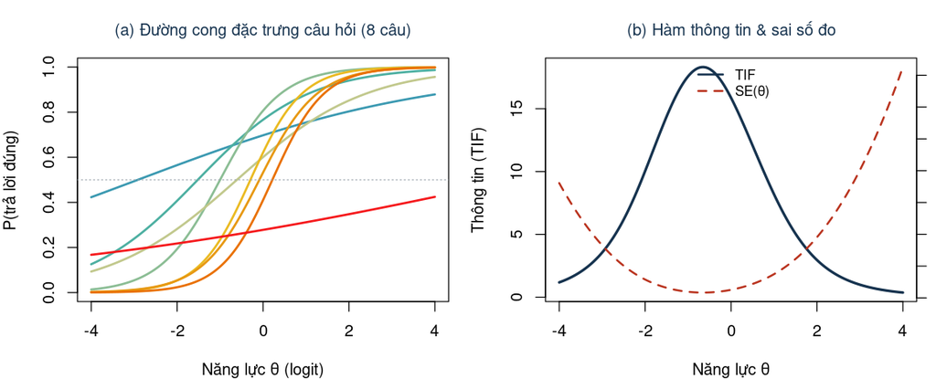

**Hình 6.** Đường cong đặc trưng của 8 câu (trái) và hàm thông tin / sai số đo của cả đề (phải), ước lượng thật bằng mô hình 2PL. Đường thoải = phân biệt kém; nơi TIF cao thì SE thấp.

### 4.2. Tính bất biến — "hòn đá tảng" trên dữ liệu thật

Đây là ưu thế cốt lõi ở mục 2.3, kiểm chứng trên dữ liệu thật. Chia thí sinh thành nhóm yếu và nhóm giỏi rồi đo lại độ khó từng câu trong mỗi nhóm. Theo **CTT** (trái), "độ khó" = tỷ lệ trả lời đúng **đổi hẳn theo nhóm**: nhóm giỏi thấy mọi câu dễ hơn nên mọi điểm nằm lệch hẳn lên trên đường chéo. Theo **IRT** (phải), độ khó b (sau khi canh tâm) **được bảo toàn** — các điểm bám sát đường chéo. Tham số IRT về nguyên tắc không phụ thuộc nhóm thí sinh dùng để định cỡ; điểm CTT thì có.

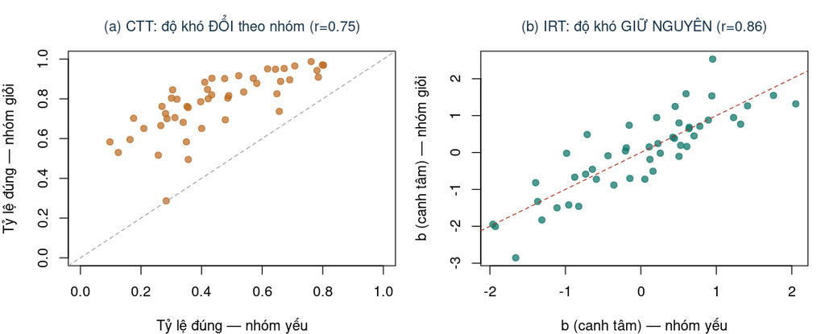

### 4.3. Khi giả định độc lập địa phương bị vi phạm

Đề có các câu Đúng/Sai chùm — mỗi câu gồm 4 ý (a–d) chung một ngữ cảnh. Khi tách 4 ý thành 4 câu nhị phân độc lập, giả định **độc lập địa phương** (mục 1.2, 3.2) bị vi phạm: sau khi đã trừ ảnh hưởng của năng lực, các ý cùng một câu vẫn còn tương quan mạnh — hiện thành các **khối đỏ đậm 4×4** trên bản đồ phần dư Q3 (mục 3.8). Hệ quả là phóng đại độ tin cậy và lượng thông tin; cách xử lý là gộp mỗi câu chùm thành một item đa mức (chấm 0–4 điểm).

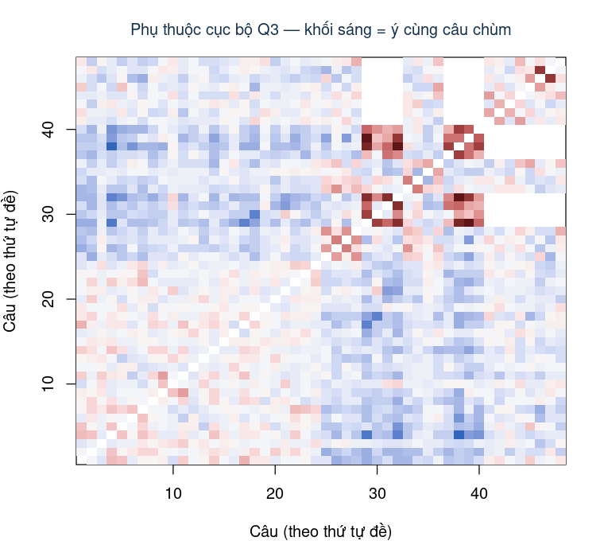

**Hình 8.** Bản đồ phụ thuộc cục bộ Q3. Khối sáng (đỏ) ngoài đường chéo = các ý cùng một câu Đúng/Sai chùm còn dính nhau ngoài năng lực chung. Ô trắng = cặp câu không thí sinh nào làm chung (do đề phân nhánh).

### 4.4. Câu hỏi thiên lệch (DIF)

IRT trả lời được câu hỏi mà CTT bất lực: "ở *cùng* một mức năng lực, hai nhóm thí sinh có xác suất trả lời đúng như nhau không?" (mục 3.9). Đề này cho thí sinh chọn một trong hai phân môn — Khoa học máy tính hoặc Tin học ứng dụng — tạo thành một phép so nhóm tự nhiên. Với một câu bị đánh dấu DIF, ở cùng mức năng lực hai nhóm lại có tỷ lệ trả lời đúng khác nhau (hai đường tách nhau) — dấu hiệu câu **thiên lệch** theo nhóm, cần rà soát nội dung.

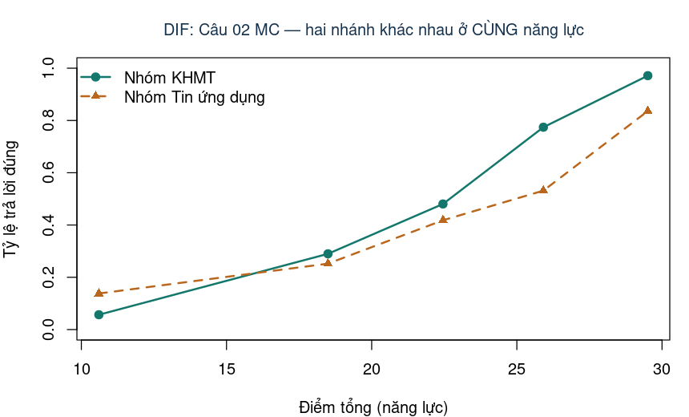

**Hình 9.** Câu hỏi thiên lệch (DIF). Tỷ lệ trả lời đúng theo mức năng lực, tách riêng cho hai nhóm phân môn. Hai đường tách nhau ở cùng năng lực ⇒ câu hoạt động khác nhau giữa hai nhóm.

### 4.5. Lựa chọn mô hình: phù hợp tương đối và tuyệt đối

Chọn mô hình cần đọc đồng thời hai loại chỉ số (mục 3.3, 3.8). **AIC/BIC** (tương đối, càng nhỏ càng tốt) ở đề này chọn **2PL** — thêm tham số đoán mò của 3PL không bõ phần phạt. **RMSEA** (tuyệt đối) của cả ba mô hình đều dưới 0,06 (đạt), 3PL thấp nhất nhưng AIC/BIC vẫn không chọn do nguyên tắc tiết kiệm tham số. Lưu ý: nếu RMSEA cao thì dù AIC/BIC có chọn, mô hình "tốt nhất" vẫn chưa thực sự khớp dữ liệu — đây là lý do phải đọc kèm fit tuyệt đối.

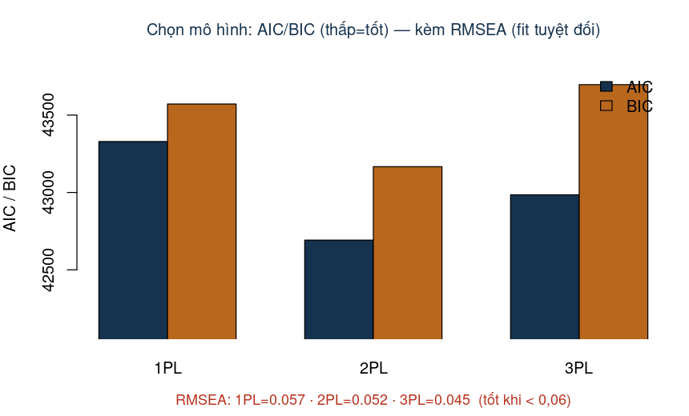

**Hình 10.** Chỉ số chọn mô hình. AIC/BIC (cột) chọn 2PL; RMSEA (dòng dưới) cho biết độ phù hợp tuyệt đối — ở đây cả ba mô hình đều đạt (< 0,06).

Tài liệu tham khảo

Tài liệu tham khảo

1. Lâm Quang Thiệp (2011). Đo lường trong giáo dục: Lý thuyết và ứng dụng. Hà Nội: NXB Đại học Quốc gia Hà Nội.

2. Rasch, G. (1960). Probabilistic Models for Some Intelligence and Attainment Tests. Copenhagen: Danmarks Pædagogiske Institut.

3. Lord, F. M. (1980). Applications of Item Response Theory to Practical Testing Problems. Hillsdale, NJ: Lawrence Erlbaum.

4. Birnbaum, A. (1968). Some latent trait models and their use in inferring an examinee's ability. Trong F. M. Lord & M. R. Novick, Statistical Theories of Mental Test Scores (tr. 397–479). Reading, MA: Addison-Wesley.

5. Hambleton, R. K., Swaminathan, H., & Rogers, H. J. (1991). Fundamentals of Item Response Theory. Newbury Park, CA: Sage.

6. Baker, F. B., & Kim, S.-H. (2004). Item Response Theory: Parameter Estimation Techniques (2nd ed.). New York: Marcel Dekker.

7. Bock, R. D., & Mislevy, R. J. (1982). Adaptive EAP estimation of ability in a microcomputer environment. Applied Psychological Measurement, 6(4), 431–444.

8. Wright, B. D., & Masters, G. N. (1982). Rating Scale Analysis. Chicago: MESA Press.